# InSuKa: Descriptive Statistics and R Script

Indra Chintakayala, Wancheng Sun, Kalapna Jha

October 30, 2018

[figure not shown]

[figure not shown]

# 1 .R Packages required

Make sure you have latest R and Rstudio installed before starting this process. These are the R packages that are required to complete the data cleaning and documentation using Rstudio.

- knitr - for rendering HTML reports
- tidyverse - for data manupulations

**Note:** The above packages do not come with Rstudio installation, they need to be installed explictly, use the packages tab or just type install.packages(“package_name”).

Next load the R packages:

```r
#install those packages before run the rmd if there is no package following codes:
#install.packages(c("rio","data.table","dplyr","anytime","knitr","kableExtra", "ggplot2","ISOweek","alluvial","lubridate"))
library("knitr")
library("tidyverse")
```

# 2 .Avian Monitoring - eBird

## 2.1 Data Preparation

> Reshaped data of Avia Monitoring

We reshape some data format and create some new columns which are easy and convient for the following analysis.

| Monitoring_Route | Date | eBird | eachCount | totalCount | H_S | variable | value | Weeks | WeekNoYear | Year | Month | MonthWithYear | season |
| --- | --- | --- | --- | --- | --- | --- | --- | --- | --- | --- | --- | --- | --- |
| Purple Trail | 2016-08-31 | N | 17 | 13 |  |  |  | 2016-W35 | W35 | 2016 | 8 | 2016-08 | summer |
| Green Trail | 2017-04-03 | N | 5 | 4 | Heard | CAGO | 2 | 2017-W14 | W14 | 2017 | 4 | 2017-04 | spring |
| Red Trail | 2018-07-11 | N | 8 | 5 |  |  |  | 2018-W28 | W28 | 2018 | 7 | 2018-07 | summer |
| Green Trail | 2016-07-19 | N | 5 | 5 |  |  |  | 2016-W29 | W29 | 2016 | 7 | 2016-07 | summer |
| Purple Trail | 2018-06-07 | N | 5 | 4 |  |  |  | 2018-W23 | W23 | 2018 | 6 | 2018-06 | summer |

> Data from eBird

With the limited access to eBird dataset, we cannot compare this example data with our data directly, we just take this part of example data from eBird website as reference, whcih will make the following analysis easier.

| Week_starting_on | species | Frequency | Total_checklists_submitted | Abundance | Birds_Per_Party_Hour | checklists_reporting_species | High_Count | checklists_reporting_species__1 | Totals | checklists_reporting_species__2 | Average_Count | checklists_reporting_species__3 | variable |
| --- | --- | --- | --- | --- | --- | --- | --- | --- | --- | --- | --- | --- | --- |
| 02-07 | Common Yellowthroat | 0.0000000 | 7679 | 0.0000000 | 0.000000 | 0 | 0 | 0 | 0 | 0 | 0.000000 | 0 | Common Yellowthroat |
| 01-07 | Marsh Wren | 0.0529101 | 5670 | 0.0005291 | 2.351564 | 3 | 1 | 3 | 3 | 3 | 1.000000 | 3 | MAWR |
| 08-14 | Canada Goose | 28.3185841 | 3503 | 7.3011704 | 43.862224 | 994 | 350 | 1029 | 26305 | 1000 | 26.305000 | 1000 | CAGO |
| 01-21 | Great Blue Heron | 8.4825117 | 7262 | 0.1817681 | 5.347221 | 633 | 24 | 665 | 1382 | 662 | 2.087613 | 662 | GBHE |
| 08-31 | Marsh Wren | 0.9322974 | 4505 | 0.0142064 | 1.220736 | 43 | 4 | 44 | 65 | 43 | 1.511628 | 43 | MAWR |

## 2.2 Descriptive Analysis

| variable | min | median | mean | max |
| --- | --- | --- | --- | --- |
| MAWR | 1 | 4 | 5.000000 | 11 |
| GBHE | 1 | 3 | 8.000000 | 30 |
| WOTH | 1 | 1 | 2.000000 | 6 |
| WODU | 1 | 3 | 3.428571 | 5 |
| CAGO | 1 | 2 | 8.357143 | 29 |

### 2.2.1 Cross Table

> With season

First, we compare these five speices seasonally which includes autumn, spring, summer and winter.

| variable | autumn | spring | summer | winter |
| --- | --- | --- | --- | --- |
| CAGO | 22 | 63 | 1 | 31 |
| MAWR | 0 | 1 | 19 | 0 |
| GBHE | 1 | 18 | 85 | 0 |
| WODU | 5 | 3 | 16 | 0 |
| WOTH | 0 | 0 | 14 | 0 |

> With Monitoring Route

Secondly, we compare thesee five species based on Monitoring_Route which includes Blue Trail, Green Trail, Purpule Trail and Red Trail.

| variable | Blue Trail | Green Trail | Purple Trail | Red Trail |
| --- | --- | --- | --- | --- |
| CAGO | 105 | 6 | 2 | 4 |
| MAWR | 20 | 0 | 0 | 0 |
| GBHE | 103 | 1 | 0 | 0 |
| WODU | 24 | 0 | 0 | 0 |
| WOTH | 0 | 1 | 1 | 12 |

> With H_S

Thirdly, we comare these five species based on H_S which means the species both heard and seen, headred, seen seperately.

| variable | H&S | Heard | Seen |
| --- | --- | --- | --- |
| CAGO | 2 | 12 | 103 |
| MAWR | 0 | 14 | 6 |
| GBHE | 10 | 10 | 84 |
| WODU | 6 | 0 | 18 |
| WOTH | 1 | 10 | 3 |

> With Year

Forthly, we coompare these five species yearly which mainly focues on 2016, 2017, 2018 years.

| variable | 2016 | 2017 | 2018 |
| --- | --- | --- | --- |
| CAGO | 24 | 72 | 21 |
| MAWR | 11 | 1 | 8 |
| GBHE | 30 | 33 | 41 |
| WODU | 13 | 9 | 2 |
| WOTH | 7 | 2 | 5 |

## 2.3 ANOVA Analysis

According to descriptive part, We can be sure each variable with each species in the sample is not homogeneous. But five species have their unique characters on each variable, and we may eplore more relationship on the variables.

The total number of observation in MAWR, WOTH and WODU is not much enough to well estimate the variables difference in the sample. We will only take a trying to test anova group defference on the two species(CAGO, GBHE).

### 2.3.1 Canada Goose(CAGO)

```r
#Randomized Block Design
fit <- aov(value ~ H_S + Year + Monitoring_Route + season, aviaAllu[variable == "CAGO",])
anova(fit)
```

```
## Analysis of Variance Table
##
## Response: value
##                  Df Sum Sq Mean Sq F value Pr(>F)
## H_S               2 565.79 282.893  2.0096 0.2488
## Year              1   7.49   7.494  0.0532 0.8288
## Monitoring_Route  3 301.97 100.657  0.7150 0.5924
## season            3  86.87  28.956  0.2057 0.8876
## Residuals         4 563.10 140.774
```

As the result shows, we can not reject the null hypothesis on 5%, GAGO’s observation number in the four variables has no significant different.

### 2.3.2 Great blue hero(GBHE)

```r
#Randomized Block Design
fit <- aov(value ~ H_S +  season + Year + Monitoring_Route, aviaAllu[variable == "GBHE",])
anova(fit)
```

```
## Analysis of Variance Table
##
## Response: value
##                  Df Sum Sq Mean Sq F value  Pr(>F)
## H_S               2 414.00 207.000  3.7619 0.08733 .
## season            2 356.36 178.182  3.2382 0.11122
## Year              1  15.99  15.988  0.2906 0.60926
## Monitoring_Route  1  61.50  61.499  1.1177 0.33112
## Residuals         6 330.15  55.025
## ---
## Signif. codes:  0 '***' 0.001 '**' 0.01 '*' 0.05 '.' 0.1 ' ' 1
```

```r
# Two Way Factorial Design
fit <- aov(value ~  season * H_S, aviaAllu[variable == "GBHE",])
anova(fit)
```

```
## Analysis of Variance Table
##
## Response: value
##            Df Sum Sq Mean Sq F value  Pr(>F)
## season      2 265.94 132.971  3.2609 0.11002
## H_S         2 504.42 252.210  6.1850 0.03484 *
## season:H_S  2 162.97  81.485  1.9983 0.21622
## Residuals   6 244.67  40.778
## ---
## Signif. codes:  0 '***' 0.001 '**' 0.01 '*' 0.05 '.' 0.1 ' ' 1
```

# 3 .Avian Monitoring - Indicator Species

```
## 'data.frame':    395 obs. of  21 variables:
##  $ Date : Date, format: "2016-07-10" "2016-07-10" ...
##  $ Month: int  7 7 7 7 7 7 7 7 7 7 ...
##  $ Day  : int  10 10 10 10 10 10 10 10 10 10 ...
##  $ Year : int  2016 2016 2016 2016 2016 2016 2016 2016 2016 2016 ...
##  $ EABL : int  NA NA NA NA NA NA NA NA NA NA ...
##  $ WBNU : int  NA NA NA NA NA NA NA NA NA NA ...
##  $ COYE : int  NA NA NA NA NA NA NA NA NA NA ...
##  $ EAKI : int  NA NA NA NA NA NA NA NA NA NA ...
##  $ MALL : int  NA NA NA NA NA NA NA NA NA 1 ...
##  $ CAGO : int  NA NA NA NA NA NA NA NA NA NA ...
##  $ MODO : int  NA NA NA NA NA NA 1 NA 1 NA ...
##  $ MAWR : int  1 NA NA NA 1 NA NA NA NA NA ...
##  $ CATE : int  NA NA NA NA NA NA NA NA NA NA ...
##  $ GREG : int  2 NA 1 1 NA NA NA NA NA NA ...
##  $ WODU : int  NA NA NA NA NA NA NA NA NA NA ...
##  $ GBHE : int  1 1 NA NA NA 1 NA NA NA NA ...
##  $ RBWO : int  NA NA NA NA NA NA NA NA NA NA ...
##  $ WOTH : int  NA NA NA NA NA NA NA NA NA NA ...
##  $ GRFL : int  NA NA NA NA NA NA NA 1 NA NA ...
##  $ AMRE : int  NA NA NA NA NA NA NA NA NA NA ...
##  $ EATO : int  NA NA NA NA NA NA NA NA NA NA ...
```

```
##       Date                Month             Day             Year
##  Min.   :2016-07-10   Min.   : 1.000   Min.   : 1.00   Min.   :2016
##  1st Qu.:2016-07-29   1st Qu.: 6.000   1st Qu.: 9.00   1st Qu.:2016
##  Median :2017-04-03   Median : 7.000   Median :17.00   Median :2017
##  Mean   :2017-05-01   Mean   : 6.706   Mean   :16.37   Mean   :2017
##  3rd Qu.:2018-04-08   3rd Qu.: 8.000   3rd Qu.:23.00   3rd Qu.:2018
##  Max.   :2018-08-08   Max.   :12.000   Max.   :31.00   Max.   :2018
##
##       EABL          WBNU            COYE          EAKI
##  Min.   :1.0   Min.   :1.000   Min.   :1     Min.   :1.00
##  1st Qu.:1.0   1st Qu.:1.000   1st Qu.:1     1st Qu.:1.00
##  Median :1.0   Median :1.000   Median :1     Median :1.00
##  Mean   :1.8   Mean   :1.094   Mean   :1     Mean   :1.25
##  3rd Qu.:2.0   3rd Qu.:1.000   3rd Qu.:1     3rd Qu.:1.25
##  Max.   :5.0   Max.   :2.000   Max.   :1     Max.   :2.00
##  NA's   :385   NA's   :363     NA's   :381   NA's   :391
##       MALL            CAGO             MODO            MAWR
##  Min.   :1.000   Min.   : 1.000   Min.   :1.000   Min.   :1.000
##  1st Qu.:1.000   1st Qu.: 1.000   1st Qu.:1.000   1st Qu.:1.000
##  Median :1.000   Median : 2.000   Median :1.000   Median :1.000
##  Mean   :1.632   Mean   : 3.297   Mean   :1.273   Mean   :1.261
##  3rd Qu.:1.500   3rd Qu.: 3.000   3rd Qu.:1.750   3rd Qu.:1.000
##  Max.   :6.000   Max.   :20.000   Max.   :2.000   Max.   :3.000
##  NA's   :376     NA's   :358      NA's   :373     NA's   :372
##       CATE          GREG           WODU            GBHE
##  Min.   :1     Min.   :1.00   Min.   :1.000   Min.   :1.000
##  1st Qu.:1     1st Qu.:1.00   1st Qu.:1.000   1st Qu.:1.000
##  Median :1     Median :1.00   Median :1.000   Median :1.000
##  Mean   :1     Mean   :1.25   Mean   :2.053   Mean   :1.265
##  3rd Qu.:1     3rd Qu.:1.00   3rd Qu.:3.000   3rd Qu.:1.000
##  Max.   :1     Max.   :5.00   Max.   :5.000   Max.   :3.000
##  NA's   :392   NA's   :331    NA's   :376     NA's   :293
##       RBWO            WOTH            GRFL            AMRE
##  Min.   :1.000   Min.   :1.000   Min.   :1.000   Min.   :2
##  1st Qu.:1.000   1st Qu.:1.000   1st Qu.:1.000   1st Qu.:2
##  Median :1.000   Median :1.000   Median :1.000   Median :2
##  Mean   :1.082   Mean   :1.077   Mean   :1.077   Mean   :2
##  3rd Qu.:1.000   3rd Qu.:1.000   3rd Qu.:1.000   3rd Qu.:2
##  Max.   :3.000   Max.   :2.000   Max.   :2.000   Max.   :2
##  NA's   :346     NA's   :382     NA's   :382     NA's   :394
##       EATO
##  Min.   :1.000
##  1st Qu.:1.000
##  Median :1.000
##  Mean   :1.222
##  3rd Qu.:1.000
##  Max.   :2.000
##  NA's   :386
```

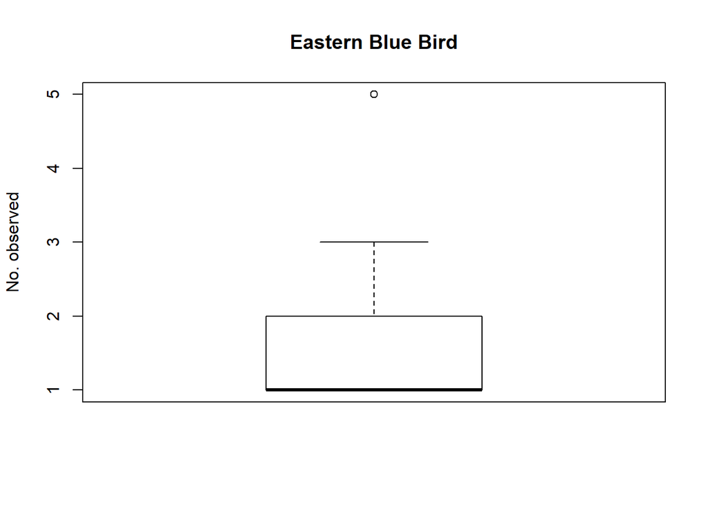

```r
boxplot(avian$EABL, main = 'Eastern Blue Bird', ylab='No. observed')
```

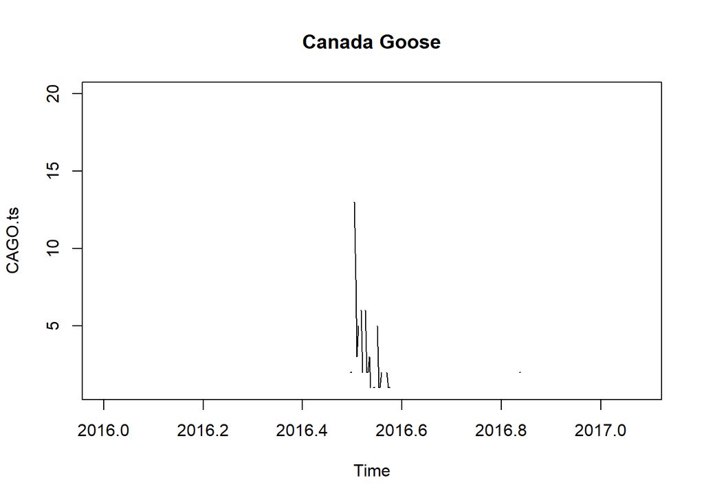

```r
CAGO.ts<- ts(avian$CAGO,start = c(2016), frequency = 365)
  plot(CAGO.ts, main = 'Canada Goose')
```

# 4 Bald Eagle Nesting

Based on Research questions, we have identified the following variables that are useful in deriving our data insights and conclusions. There are two types of data that are observed by the scientists/volunteers in same dataset i.e, Quantitative data and Qualitative data.

## 4.1 Qualitative Data Variables:

The following data values are descriptive and non-numeric.

- NestStatus
- NestCondition
- BirdsPresent&Plumages
- BirdsonNest
- AprroxEggs
- ApproxChicks

Setting the working directory and reading the cleaned data:

```r
setwd("C:/Users/indra/Desktop/Week12/OldWomanCreek/Deliverables/RScript") # setting the working dir
eagle_raw_data <- read.csv("BaldEagle.csv") # reading the csv data
```

‘eagle_raw_data’ stores the whole dataset from csv file. We make data manupulations of the variable ‘eagle_raw_data’.

### 4.1.1 Frequency Distribution of Qualitative Data:

```r
NestStatus = eagle_raw_data$NestStatus # select NestStatus from raw data
NestStatus.freq = table(NestStatus) # Apply the table function
```

NestStatus.freq stores the frequency of each occurence. Lets view the frequecy distribution:

```r
kable(NestStatus.freq) # view the distributions
```

| NestStatus | Freq |
| --- | --- |
|  | 87 |
| A | 4 |
| B | 59 |
| BR | 33 |
| Branching | 82 |
| Building | 5 |
| Building/Guarding | 4 |
| F | 1 |
| Fledged | 2 |
| Guarding | 4 |
| Guarding | 1 |
| H | 665 |
| Hatched | 85 |
| I | 521 |
| Incubating | 22 |
| Incubating/Hatched | 12 |
| Old Nest | 2 |
| Protecting | 3 |
| R | 86 |

Similarly, we can get the frequency distribution for other qualitative variables. We are working on using this frequency to get the plots by joining the Quantitative data.

### 4.1.2 Relative Frequency Distribution of Qualitative Data

> The relative frequency distribution of a data variable is a summary of the frequency proportion in a collection of non-overlapping categories. [2]

The relationship of frequency and relative frequency is:

```r
NestStatus.relfreq = NestStatus.freq / nrow(eagle_raw_data) # calculating the relative freq.
```

Rounding the decimal frequencies to ‘3’ digits.

```r
old = options(digits = 3)
kable(NestStatus.relfreq)
```

| NestStatus | Freq |
| --- | --- |
|  | 0.052 |
| A | 0.002 |
| B | 0.035 |
| BR | 0.020 |
| Branching | 0.049 |
| Building | 0.003 |
| Building/Guarding | 0.002 |
| F | 0.001 |
| Fledged | 0.001 |
| Guarding | 0.002 |
| Guarding | 0.001 |
| H | 0.396 |
| Hatched | 0.051 |
| I | 0.310 |
| Incubating | 0.013 |
| Incubating/Hatched | 0.007 |
| Old Nest | 0.001 |
| Protecting | 0.002 |
| R | 0.051 |

```r
options(old)
```

### 4.1.3 Barplot for Frequency

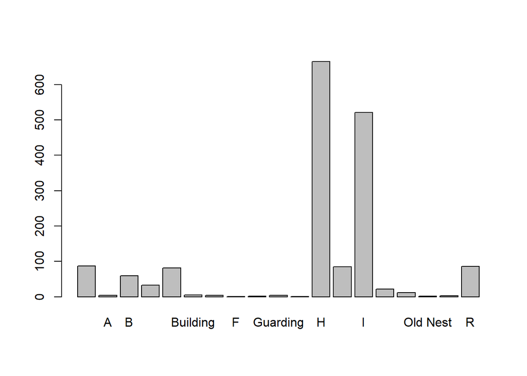

```r
barplot(NestStatus.freq)
```

### 4.1.4 Pie Chart for Frequency

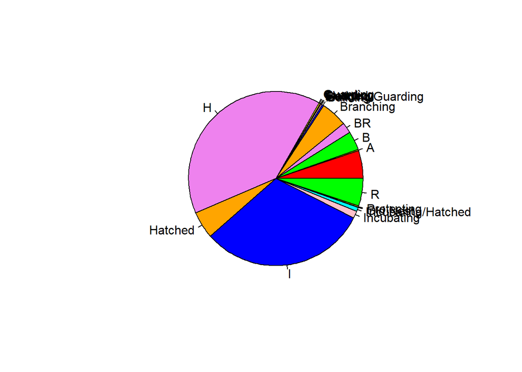

```r
colors = c("red", "yellow", "green", "violet", "orange", "blue", "pink", "cyan")
pie(NestStatus.freq, col=colors)
```

### 4.1.5 Category Statistics

H - stands for hatching Nest Status. To find mean temperature(F) for ‘Nest Status’ = H.

Create logical vector for NestStatus = H:

```r
H_NestStatus = NestStatus =='H'
```

```r
H_eagle_raw_data = eagle_raw_data[H_NestStatus,]
```

Now, find the mean Temperature(F) of NestStatus = H:

```r
round(mean(H_eagle_raw_data$Temp), digits = 2)
```

```
## [1] 59.84
```

The average mean temperature for NestStatus = Hatching is 59.84

Similarly, summary will show the quantile, median, Min, Max and Mean values for temperature when NestStatus = H:

```r
summary(H_eagle_raw_data$Temp)
```

```
##    Min. 1st Qu.  Median    Mean 3rd Qu.    Max.
##   35.00   51.00   55.00   59.84   70.00   90.00
```

## 4.2 Quantitative Data Variables:

The following data values are non-descriptive and numeric.

- Temp
- Wind-Velocity
- Wind-Direction
- Precipatation
- CloudCover

# 5 .Contributorship

Indra - I worked on Bald eagle, github.

Sun - Worked on eBird Data, github

Kalpana - worked on Indicator species, github and proofreading.

# 6 .References

[Rmarkdown Authoring Basics](https://rmarkdown.rstudio.com/authoring_basics.html)

[R Notebooks](https://blog.rstudio.com/2016/10/05/r-notebooks/)

[Latex equation editor](http://www.sciweavers.org/free-online-latex-equation-editor)

[QUalitative Stats in R](http://www.r-tutor.com/elementary-statistics/qualitative-data)

[Create Awesome HTML Table with knitr::kable and kableExtra](https://cran.r-project.org/web/packages/kableExtra/vignettes/awesome_table_in_html.html)

[Meteorological season](https://en.wikipedia.org/wiki/Season)

[Creating Alluvial Diagrams](https://cran.r-project.org/web/packages/alluvial/vignettes/alluvial.html)

[Factorial Treatment Structure](https://stat.ethz.ch/~meier/teaching/anova/factorial-treatment-structure.html)

[Two way - between subject analysis of variance](http://personality-project.org/r/r.guide/r.anova.html)

[Bird Observations - eBird](https://ebird.org/barchart?byr=2016&eyr=2018&bmo=1&emo=12&r=US-OH)

[ggplot2 Cheatsheet](https://ggplot2.tidyverse.org)